# Comments on ‘Imbalance in gut microbial interactions as a marker of health and disease’ from Corral López et al. (2026)

## 3 Conclusion

In this work, we reassessed the relationship between microbial interaction imbalance and disease status across multiple gut microbiome datasets. While increased net positive interactions in diseased samples were observed in IBD and CDI, this pattern was not consistent across all conditions. Notably, the CRC dataset from Yachida et al. (2019) exhibited the opposite trend, with higher net interaction values in healthy samples, a result that was robust across inference methods and subsampling strategies. Consequently, these findings do not support the claim that microbial interaction imbalance constitutes a universal signature of disease, but rather suggest that such metrics are context-dependent.

## 4 References

Corral López, Roberto, Juan A. Bonachela, Maria Gloria Dominguez-Bello, et al. 2026. “Imbalance in Gut Microbial Interactions as a Marker of Health and Disease.” *Science* 391 (6788): 890–95. https://doi.org/10.1126/science.ady1729.

Ferretti, Pamela, Jakob Wirbel, Oleksandr M Maistrenko, et al. 2023. *C. Difficile May Be Overdiagnosed in Adults and Is a Prevalent Commensal in Infants*. https://doi.org/10.7554/elife.90111.1.

Franzosa, Eric A., Alexandra Sirota-Madi, Julian Avila-Pacheco, et al. 2018. “Gut Microbiome Structure and Metabolic Activity in Inflammatory Bowel Disease.” *Nature Microbiology* 4 (2): 293–305. https://doi.org/10.1038/s41564-018-0306-4.

Lloyd-Price, Jason, Cesar Arze, Ashwin N. Ananthakrishnan, et al. 2019. “Multi-Omics of the Gut Microbial Ecosystem in Inflammatory Bowel Diseases.” *Nature* 569 (7758): 655–62. https://doi.org/10.1038/s41586-019-1237-9.

Vogtmann, Emily, Xing Hua, Georg Zeller, et al. 2016. “Colorectal Cancer and the Human Gut Microbiome: Reproducibility with Whole-Genome Shotgun Sequencing.” *PLOS ONE* 11 (5): e0155362. https://doi.org/10.1371/journal.pone.0155362.

Wirbel, Jakob, Paul Theodor Pyl, Ece Kartal, et al. 2019. “Meta-Analysis of Fecal Metagenomes Reveals Global Microbial Signatures That Are Specific for Colorectal Cancer.” *Nature Medicine* 25 (4): 679–89. https://doi.org/10.1038/s41591-019-0406-6.

Yachida, Shinichi, Sayaka Mizutani, Hirotsugu Shiroma, et al. 2019. “Metagenomic and Metabolomic Analyses Reveal Distinct Stage-Specific Phenotypes of the Gut Microbiota in Colorectal Cancer.” *Nature Medicine* 25 (6): 968–76. https://doi.org/10.1038/s41591-019-0458-7.

Zeller, Georg, Julien Tap, Anita Y Voigt, et al. 2014. “Potential of Fecal Microbiota for Early‐stage Detection of Colorectal Cancer.” *Molecular Systems Biology* 10 (11). https://doi.org/10.15252/msb.20145645.

## Supplementary Figures

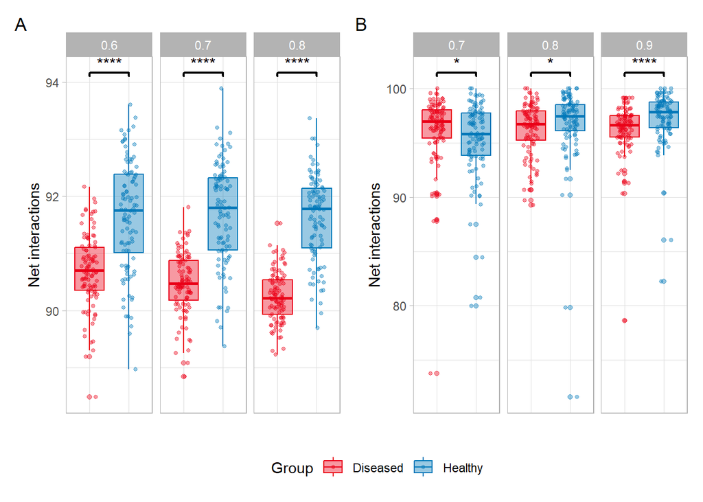

Figure 4: PEP results for the CRC dataset from Yachida et al. (2019) on 100 bootstrap iterations. (A) PEP results for the CRC dataset using the FlashWeave tool assuming homogeneous samples (`heterogeneous = FALSE`) across 60, 70 and 80% subsampling. (B) PEP results for the CRC dataset using the BEEM-Static tool with a 30% prevalence filtering across 70, 80 and 90% subsampling .

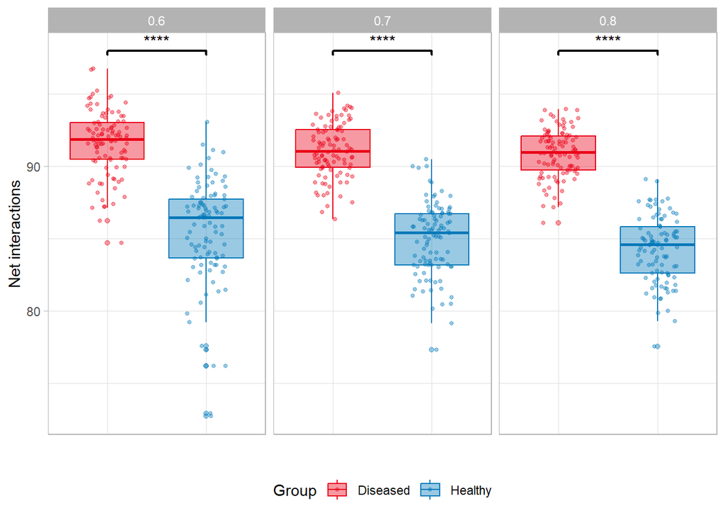

Figure 5: Net interactions results for the IBD dataset from Franzosa et al. (2018) across 60, 70 and 80% subsampling on 100 bootstrap iterations using the FlashWeave tool assuming homogeneous samples (`heterogeneous = FALSE`).

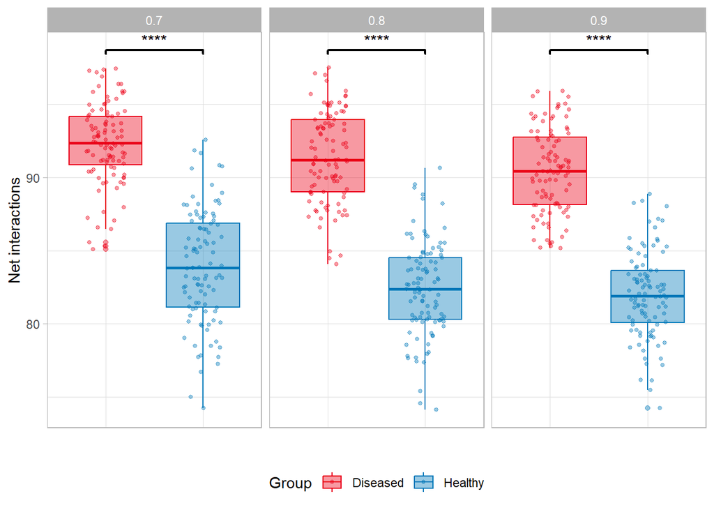

Figure 6: Net interactions results for the IBD dataset from Franzosa et al. (2018) across 70, 80 and 90% subsampling on 100 bootstrap iterations using the BEEM-Static tool with a 30% prevalence filtering.